# Introduction to model evaluation

Data Science for Biologists, Spring 2020

Paige Richards

## Instructions

Standard grading criteria apply, except there is no “answer style” - just write out answers normally! **Make sure your bulleted lists render appropriately in the knitted output!!!**

This assignment will use an external dataset of various physical measurements from 250 adult males. Our goal for this assignment is to build and evaluate a model from this data to **predict body fat percentage** (column `Percent`) in adult males, and then use this model to predict future outcomes. Age is measured in years, weight in pounds, height in inches, and all other measurements are circumference measured in cm.

```r
fatmen <- read_csv("https://raw.githubusercontent.com/sjspielman/datascience_for_biologists/master/data/bodyfat.csv")
## Parsed with column specification:
## cols(
##   Percent = col_double(),
##   Age = col_double(),
##   Weight = col_double(),
##   Height = col_double(),
##   Neck = col_double(),
##   Chest = col_double(),
##   Abdomen = col_double(),
##   Hip = col_double(),
##   Thigh = col_double(),
##   Knee = col_double(),
##   Ankle = col_double(),
##   Biceps = col_double(),
##   Forearm = col_double(),
##   Wrist = col_double()
## )
dplyr::glimpse(fatmen)
## Observations: 250
## Variables: 14
## $ Percent <dbl> 12.3, 25.3, 10.4, 20.9, 19.2, 12.4, 4.1, 11.7, 7.1, 7.8, 20.8…
## $ Age     <dbl> 23, 22, 26, 24, 26, 25, 25, 23, 26, 27, 32, 30, 35, 35, 34, 3…
## $ Weight  <dbl> 154.25, 154.00, 184.75, 210.25, 181.00, 176.00, 191.00, 198.2…
## $ Height  <dbl> 67.75, 66.25, 72.25, 74.75, 69.75, 72.50, 74.00, 73.50, 74.50…
## $ Neck    <dbl> 36.2, 34.0, 37.4, 39.0, 36.4, 37.8, 38.1, 42.1, 38.5, 39.4, 3…
## $ Chest   <dbl> 93.1, 95.8, 101.8, 104.5, 105.1, 99.6, 100.9, 99.6, 101.5, 10…
## $ Abdomen <dbl> 85.2, 87.9, 86.4, 94.4, 90.7, 88.5, 82.5, 88.6, 83.6, 90.9, 9…
## $ Hip     <dbl> 94.5, 99.2, 101.2, 107.8, 100.3, 97.1, 99.9, 104.1, 98.2, 107…
## $ Thigh   <dbl> 59.0, 59.6, 60.1, 66.0, 58.4, 60.0, 62.9, 63.1, 59.7, 66.2, 6…
## $ Knee    <dbl> 37.3, 38.9, 37.3, 42.0, 38.3, 39.4, 38.3, 41.7, 39.7, 39.2, 3…
## $ Ankle   <dbl> 21.9, 24.0, 22.8, 25.6, 22.9, 23.2, 23.8, 25.0, 25.2, 25.9, 2…
## $ Biceps  <dbl> 32.0, 28.8, 32.4, 35.7, 31.9, 30.5, 35.9, 35.6, 32.8, 37.2, 3…
## $ Forearm <dbl> 27.4, 25.2, 29.4, 30.6, 27.8, 29.0, 31.1, 30.0, 29.4, 30.2, 2…
## $ Wrist   <dbl> 17.1, 16.6, 18.2, 18.8, 17.7, 18.8, 18.2, 19.2, 18.5, 19.0, 1…
```

## Part 1: Build a model using AIC stepwise model selection

Using the `step()` function, determine the most appropriate model to explain variation in bodyfat percentage in this data. Examine the model output with the `summary` function, and answer questions below. **You will use this model (aka you will specify these predictors) for all model evaluation questions.**

```r
## Use step() to build and save a model to explain Percent. PLEASE use the argument trace=F when calling step()!!
#if we wanted to build a linear model:
#lm(Percent ~ , data = fatmen) #percent is why. BUT WHAT DO WE USE for x? If we put in x as dot (.), that tells us all things should be used as
step( lm(Percent ~ ., data = fatmen), trace = F) -> final_model #there are many other options that are used within R in other libraries such as leap. Trace tells us we dont want to see everything step does.
#we are going to use the equation in the model for everything else

## Examine output with summary OR broom functions tidy and glance
broom::tidy(final_model)
```

```
## # A tibble: 8 x 5
##   term        estimate std.error statistic  p.value
##   <chr>          <dbl>     <dbl>     <dbl>    <dbl>
## 1 (Intercept) -33.5       9.03       -3.70 2.62e- 4
## 2 Age           0.0682    0.0313      2.18 3.03e- 2
## 3 Weight       -0.119     0.0341     -3.47 6.14e- 4
## 4 Neck         -0.374     0.225      -1.66 9.77e- 2
## 5 Abdomen       0.911     0.0705     12.9  2.22e-29
## 6 Thigh         0.219     0.116       1.88 6.13e- 2
## 7 Forearm       0.552     0.185       2.98 3.17e- 3
## 8 Wrist        -1.54      0.513      -3.01 2.88e- 3
```

```r
broom::glance(final_model) #option key gives you the opportunity to highlight vertically! It kept 7 predictors for percent
```

```
## # A tibble: 1 x 11
##   r.squared adj.r.squared sigma statistic  p.value    df logLik   AIC   BIC
##       <dbl>         <dbl> <dbl>     <dbl>    <dbl> <int>  <dbl> <dbl> <dbl>
## 1     0.742         0.734  4.30      99.2 1.91e-67     8  -715. 1449. 1480.
## # … with 2 more variables: deviance <dbl>, df.residual <int>
```

#### Part 1 questions: Answer the questions in the templated bullets!

1. In a bulleted list below, state the predictor variables for the final model and their P-values. You do not need to worry about coefficients!!
   - Age with a p-value of $3.03 \times 10^{-2}$
   - Weight with a p-value of $6.14 \times 10^{-4}$
   - Neck with a p-value of $9.77 \times 10^{-2}$
   - Abdomen with a p-value of $2.22 \times 10^{-29}$
   - Thigh with a p-value of $6.13 \times 10^{-2}$
   - Forearm with a p-value of $3.17 \times 10^{-3}$
   - Wrist with a p-value of $2.88 \times 10^{-3}$
2. What percentage of variation in bodyfat percentage is explained by this model?
   - There is 74.2% of variation in bodyfat percentage that is explained by this model.
3. What percentage of variation in bodyfat percentage is UNEXPLAINED by this model?
   - With the above being said, this would mean that 25.8% of variation in body fat is *unexplained* by this model.
4. What is the RMSE of your model? Hint: you need to run some code!

   ```r
   ## code to get RMSE of model, using the function modelr::rmse()
   modelr::rmse(final_model, fatmen) #NEED TO PUT IN THE DATQA SET USING
   ```

   ```
   ## [1] 4.231338
   ```

   - The RMSE for this model is 4.23. Consequently, the model is 4.23% off of the *actual* percentages of bodyfat.

## Part 2: Evaluate the model using several approaches

### Part 2.1: Training and testing approach

**First, use a simple train/test approach**, where the training data is a random subset comprising 65% of the total dataset. Determine the R-squared (`modelr::rsquare()`) and RMSE (`modelr::rmse()`) as determined from the training AND testing data.

```r
percent_formula <- as.formula("Percent ~ Age + Weight + Neck + Abdomen + Thigh + Forearm + Wrist") #we needed to define it as a variable so we do not mess it up later. We won't accidentally forget something. This is also helpful not to hard code

## split data into train and test, using this variable as part of your code:
training_frac <- 0.65

training_data <- dplyr::sample_frac(fatmen, training_frac)

testing_data <- dplyr::anti_join(fatmen, training_data) #whatever is not in common! Make sure to do the bigger dataset first here. This ensures that the testing data does not overlap with the training data
## Train model on training data. DO NOT USE summary(), just fit the model with the training data.
trained_model <- lm(percent_formula, data = training_data) #we built a model using the percent_formula!. We always define the formula. Usually it is Y~X but because we are using an equation for a model using step, it is different and defined above. THen we need to define the data that we are using the linear regression for and what the data that is being applied to that formula.

## Determine metrics on TRAINING data (R-squared and RMSE), using the trained model
rsquare(trained_model, data = training_data) #need to do model then data
```

```
## [1] 0.7466884
```

```r
rmse(trained_model, data = training_data) #need to do model then data
```

```
## [1] 4.22609
```

```r
## Determine metrics on TESTING data (R-squared and RMSE), using the trained model
rsquare(trained_model, data = testing_data)
```

```
## [1] 0.7117686
```

```r
rmse(trained_model, data = testing_data)
```

```
## [1] 4.330666
```

#### Part 2.1 questions: Answer the questions in the templated bullets!

1. Compare the training data $R^2$ to the testing data $R^2$. Which is higher (i.e., does the model run on training or testing data explain more variation in Percent), and is this outcome expected?
   - From here, we can see that the training $R^2$ is 0.747, while the testing $R^2$ is a bit lower at 0.712. It makes sense that the testing $R^2$ is lower than the training $R^2$ because the model is trying to be applied to data it has never seen before. Since the variation in the $R^2$ is not drastic, I do not believe the model appears to be overfitted.
2. Compare the training data *RMSE* to the testing data *RMSE*. Which is *lower* (i.e., is there more error from the model run on training or testing data), and is this outcome expected?
   - The training RMSE is 4.23; while, the RMSE for testing is 4.33. The testing data has a slightly higher error than the data that was trained. This is expected because as stated before, the model is trying to be applied to data it has never seen before. It would be unexpected for the model to do better on new data than trained data. However, looking closer at the RMSE values, they do not appear to have a signficant difference between them that would be concerning.

### Part 2.2: K-fold cross validation

Use k-fold cross validation with **15 folds** to evaluate the model. Determine the $R^2$ and RMSE for each fold, and *visualize* the distributions of $R^2$ and RMSE in two separate plots that you *add together with patchwork*. You should also calculate the mean $R^2$ and mean RMSE values.

```r
## First define the FUNCTION you will use with purrr::map which contains your linear model.
## Do NOT use step() in here - you should have used step in Part 1 to know which predictors should be included here
my_bodyfat_model <- function(input_data){
  lm(percent_formula, data = input_data)
}

## perform k-fold cross validation, using this variable in your code
number_folds <- 15

crossv_kfold(fatmen, k = number_folds) %>% #IGNORE WARNING METHOD
  mutate(model = purrr:: map(train, my_bodyfat_model), #we called it the new thing as model!
         rsquared = purrr::map2_dbl(model, test, rsquare), #that's why this is called model. We named a new column called model
         rmse_value = purrr::map2_dbl(model, test, rmse)) -> final_kfold #model then data
## Calculate the mean R^2 and RMSE
mean(final_kfold$rsquared)
```

```
## [1] 0.7171158
```

```r
mean(final_kfold$rmse_value)
```

```
## [1] 4.327703
```

```
## No summary function supplied, defaulting to `mean_se()
## No summary function supplied, defaulting to `mean_se()
```

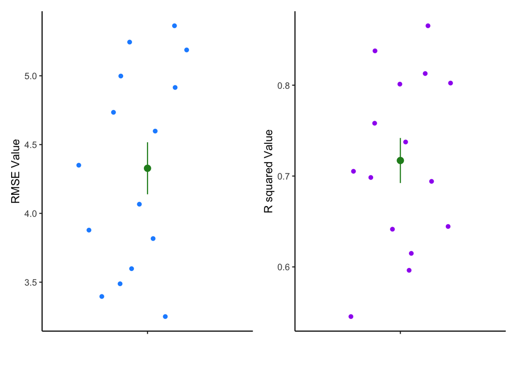

```r
## Make figures for R^2 and RMSE, which clearly show the MEAN values for each distribution using stat_summary() or similar (unless you make a boxplot, which already shows the median)

#can make a boxplot but if you don't, you need to do stat_summary!

#AN EXAMPLE!

#ggplot(final_kfold, aes(x = "", y = rmse_value)) +
  #geom_viol(alpha = 0.7) +
  #stat_summary()

ggplot(final_kfold, aes(x = "", y = rmse_value)) +
  geom_jitter(color = "dodgerblue") +
  stat_summary(color = "forestgreen") +
  labs(y = "RMSE Value",
       x = "") -> rmse_graph

ggplot(final_kfold, aes(x = "", y = rsquared)) +
  geom_jitter(color = "purple") +
  stat_summary(color = "forestgreen") +
  labs(y = "R squared Value",
       x = "") -> rsquared_graph

rmse_graph + rsquared_graph
```

#### Part 2.2 questions: Answer the questions in the templated bullets!

1. Examine your distribution of $R^2$ values. What is the average $R^2$, and how does it compare to the **testing $R^2$** from Part 1?
   - The average $R^2$ for the K fold cross validation is 0.717 and as previously mentioned in part one, the testing $R^2$ was 0.712. Interestingly, this shows that the K fold cross validation explains *fractionally* more than the trained model. It is difficult to determine if this difference is signficant or not.
2. Examine your distribution of *RMSE* values. What is the average *RMSE*, and how does it compare to the **testing RMSE** from Part 1?
   - The RMSE value of the K fold cross validation is 4.33 and the testing RMSE from part 1 was 4.33. Interestingly, the error for both the K-fold cross validation and the model are the same (when rounded).

### Part 2.3: Leave-one-out cross validation (LOOCV)

```r
## perform LOOCV (using the function my_bodyfat_model defined in Part 2.2)

crossv_loo(fatmen) %>% #IGNORE WARNING METHOD
  mutate(model = purrr:: map(train, my_bodyfat_model), #we called it the new thing as model!
        rmse_value = purrr::map2_dbl(model, test, rmse)) -> final_loo #model then data

## Calculate the mean RMSE
mean(final_loo$rmse_value)
```

```
## [1] 3.58246
```

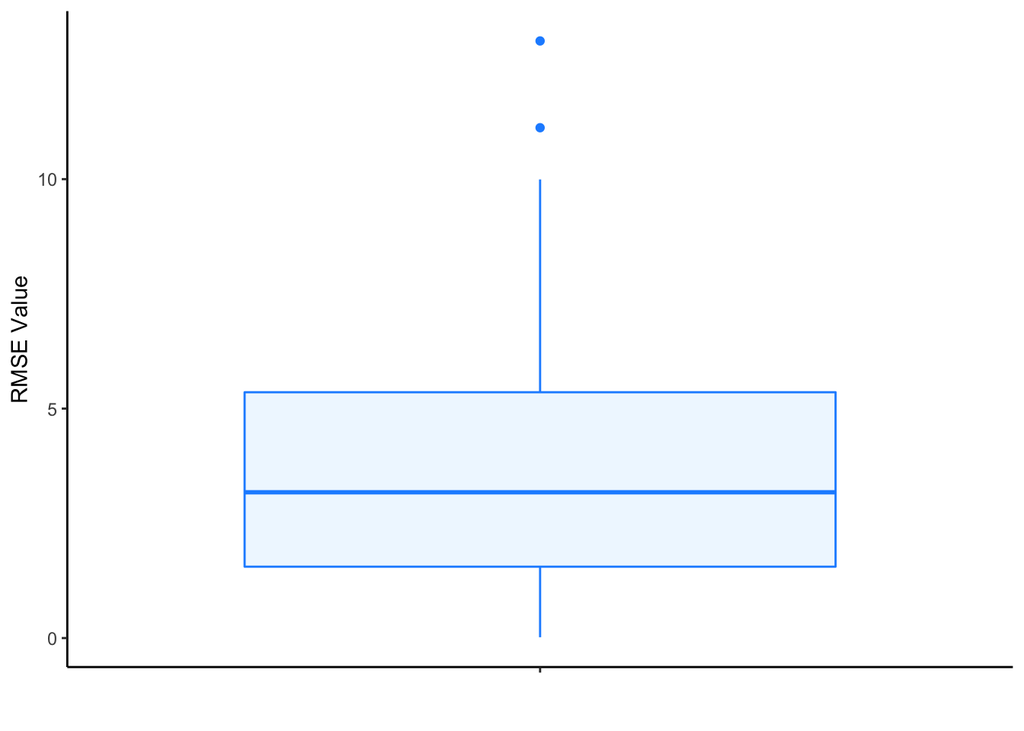

```r
## Make figure of RMSE distribution, which clearly shows the MEAN value for the distribution using stat_summary() (unless you make a boxplot, which already shows the median)
ggplot(final_loo, aes(x = "", y = rmse_value)) +
  geom_boxplot(color = "dodgerblue", fill = "aliceblue") +
  labs(x = "",
       y = "RMSE Value")
```

#### Part 2.3 question: Answer the questions in the templated bullets!

1. Examine your distribution of *RMSE* values. What is the average *RMSE*, and how does it compare to the **testing RMSE** from Part 1? How does it compare to the average *RMSE* from k-fold cross validation?
   - The RMSE value of the K fold leave one out cross validation is 3.58, while the k-fold cross validation RMSE value was 4.33. The k-fold leave one out has clearly less error than the k-fold cross validation.

### Part 2.4: Wrap-up

Considering all three approaches, do you believe this model is highly explanatory of Percent (e.g., how are the $R^2$ values)? Further, do you believe the error in this model is low, moderate or high (e.g., how are the RMSE values)? Answer in 1-2 sentences in the bullet:

- For all of these approaches, it is clear that the model would cause answers to have an error about 3-4% lower or higher than expected. When considering the data values for this model, the error is low. The range for the average $R^2$ was, at its lowest, 0.712, and its highest at 0.747. This means that the model can only explain about 72% to 75% of the data. This is generally not seen as a great model in terms of explanatory power. Usually a model that can explain the data really well would be at 95% or above. However, this is not a poor model by any means. It does have some explanatory power, but there are likely better models for this data. Overall, I would say this model is okay because it has a decent explanatory power and relatively low error.

## Part 3: Predictions

New men have arrived, and we want to use our model to predict their body fat percentages! Using the function `modelr::add_predictions()` use our model to predict what the body fat percentages will be for three men with the following physical attributes.

- Bob
  - 37 years of Age
  - Weight of 195 pounds
  - 43.6 cm Neck circumference
  - 110.6 cm Abdomen circumference
  - 71.7 cm Thigh circumference
  - 31.2 Forearm circumference
  - 19.2 Wrist circumference
- Bill
  - 65 years of Age
  - Weight of 183 pounds
  - 41.2 cm Neck circumference
  - 90.1 cm Abdomen circumference
  - 77.5 cm Thigh circumference
  - 32.2 cm Forearm circumference
  - 18.2 cm Wrist circumference
- Fred
  - 19 years of Age
  - Weight of 121 pounds
  - 30.2 cm Neck circumference
  - 68 cm Abdomen circumference
  - 48.1 cm Thigh circumference
  - 23.8 cm Forearm circumference
  - 16.1 cm Wrist circumference

```r
percent_formula <- as.formula("Percent ~ Age + Weight + Neck + Abdomen + Thigh + Forearm + Wrist")
## Make a SINGLE tibble with THREE ROWS (one per observed new man), and use this tibble to predict outcomes with `modelr::add_predictions()
## HINT: See the tidyr assignment for different ways to make a tibble directly within R
tibble(Age = c(37, 65, 19),
       Weight = c(195, 183, 121),
       Neck = c(43.6, 41.2, 30.2),
       Abdomen = c(110.6, 90.1, 68),
       Thigh = c(71.7, 77.5, 48.1),
       Forearm = c(31.2, 32.2, 23.8),
       Wrist = c(19.2, 18.2, 16.1)) -> new_men #this is how we made a tibble. Had an erorr with a comma out of place originally.

modelr::add_predictions(new_men, final_model) #data then model
```

```
## # A tibble: 3 x 8
##     Age Weight  Neck Abdomen Thigh Forearm Wrist  pred
##   <dbl>  <dbl> <dbl>   <dbl> <dbl>   <dbl> <dbl> <dbl>
## 1    37    195  43.6   111.   71.7    31.2  19.2 33.6
## 2    65    183  41.2    90.1  77.5    32.2  18.2 22.6
## 3    19    121  30.2    68    48.1    23.8  16.1  2.93
```

#### Part 3 answers:

Stick the answer after the colon for each bullet **in bold**:

- Bob’s predicted body fat percent is: **33.64%**
- Bill’s predicted body fat percent is: **22.56%**
- Fred’s predicted body fat percent is: **2.93%**

**BONUS QUESTION!** Which of the three predictions (Bob, Bill, and Fred) do you think is LEAST reliable? You may need some code to figure out which one, so add in below as needed!!

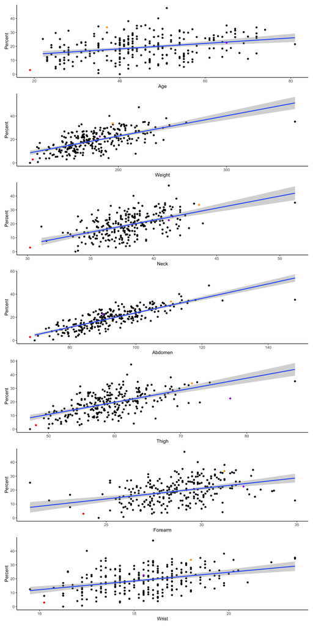

```r
ggplot(fatmen, aes(x = Age, y = Percent)) +
  geom_point()+
  geom_smooth(method = "lm") +
  annotate("point",
           y = 2.93,
           x = 19,
           color = "red") +
  annotate("point",
           y = 33.64,
           x = 37,
           color = "orange") +
  annotate("point",
           y = 22.56,
           x = 65,
           color = "purple") -> age_graph #no one underthe age of a certain age. But we will do all parameters like this and base it off the confidence interval. We will have a hard time if someone is bigger than 250 and lower than 100 pounds. Can change x by doing xlim(c(0,300)). Fred is probably the least reliable. Answer is Fred! Do at least two-three examples of ggplot
ggplot(fatmen, aes(x = Weight, y = Percent)) +
  geom_point()+
  geom_smooth(method = "lm") +
  annotate("point",
           y = 2.93,
           x = 121,
           color = "red") +
  annotate("point",
           y = 33.64,
           x = 195,
           color = "orange") +
  annotate("point",
           y = 22.56,
           x = 183,
           color = "purple") -> weight_graph

ggplot(fatmen, aes(x = Neck, y = Percent)) +
  geom_point()+
  geom_smooth(method = "lm") +
  annotate("point",
           y = 2.93,
           x = 30.2,
           color = "red") +
  annotate("point",
           y = 33.64,
           x = 43.6,
           color = "orange") +
  annotate("point",
           y = 22.56,
           x = 41.2,
           color = "purple") -> neck_graph

ggplot(fatmen, aes(x = Abdomen, y = Percent)) +
  geom_point()+
  geom_smooth(method = "lm") +
  annotate("point",
           y = 2.93,
           x = 68,
           color = "red") +
  annotate("point",
           y = 33.64,
           x = 110.6,
           color = "orange") +
  annotate("point",
           y = 22.56,
           x = 90.1,
           color = "purple") -> abdomen_graph

ggplot(fatmen, aes(x = Thigh, y = Percent)) +
  geom_point()+
  geom_smooth(method = "lm") +
  annotate("point",
           y = 2.93,
           x = 48.1,
           color = "red") +
  annotate("point",
           y = 33.64,
           x = 71.7,
           color = "orange") +
  annotate("point",
           y = 22.56,
           x = 77.5,
           color = "purple") -> thigh_graph

ggplot(fatmen, aes(x = Forearm, y = Percent)) +
  geom_point()+
  geom_smooth(method = "lm") +
  annotate("point",
           y = 2.93,
           x = 23.8,
           color = "red") +
  annotate("point",
           y = 33.64,
           x = 31.2,
           color = "orange") +
  annotate("point",
           y = 22.56,
           x = 32.2,
           color = "purple") -> forearm_graph

ggplot(fatmen, aes(x = Wrist, y = Percent)) +
  geom_point()+
  geom_smooth(method = "lm") +
  annotate("point",
           y = 2.93,
           x = 16.1,
           color = "red") +
  annotate("point",
           y = 33.64,
           x = 19.2,
           color = "orange") +
  annotate("point",
           y = 22.56,
           x = 18.2,
           color = "purple") -> wrist_graph

age_graph/weight_graph/neck_graph/abdomen_graph/thigh_graph/forearm_graph/wrist_graph
```